# Reproducible Research: Peer Assessment 1

## Loading and preprocessing the data

```r
if (!file.exists("activity.csv")) {
    unzip("activity.zip", exdir = ".")
}

data <- read.csv("activity.csv")
```

## What is mean total number of steps taken per day?

1. Calculate the total number of steps taken per day

```r
sumStepsByDay <- tapply(data$steps, data$date, sum, na.rm = TRUE)
```

2. Make a histogram of the total number of steps taken each day

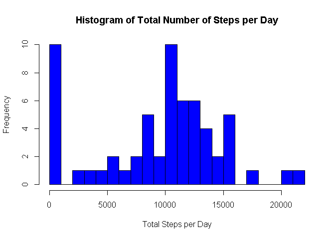

```r
hist(sumStepsByDay,
     breaks = 25,
     col = "blue",
     main = "Histogram of Total Number of Steps per Day",
     xlab = "Total Steps per Day")
```

3. Calculate and report the mean and median of the total number of steps taken per day

```r
mean(sumStepsByDay, na.rm = TRUE)
```

```
## [1] 9354.23
```

```r
median(sumStepsByDay, na.rm = TRUE)
```

```
## [1] 10395
```

## What is the average daily activity pattern?

1. Make a time series plot (i.e. type = “l”) of the 5-minute interval (x-axis) and the average number of steps taken, averaged across all days (y-axis)

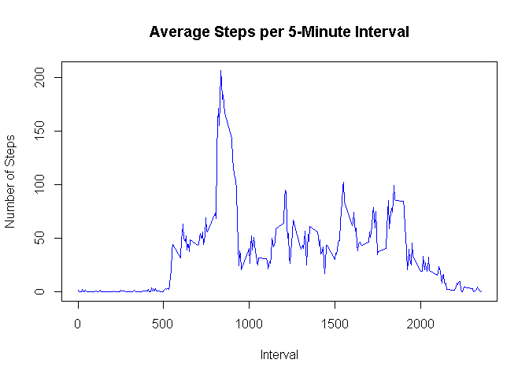

```r
avgStepsByInterval <- aggregate(x = list(steps = data$steps),
                             by = list(interval = data$interval),
                             FUN = mean,
                             na.rm = TRUE)

plot(x = avgStepsByInterval$interval,
     y = avgStepsByInterval$steps,
     type = "l",
     col = "blue",
     main = "Average Steps per 5-Minute Interval",
     xlab = "Interval",
     ylab = "Number of Steps")
```

2. Which 5-minute interval, on average across all the days in the dataset, contains the maximum number of steps?

```r
avgStepsByInterval[which.max(avgStepsByInterval$steps), ]
```

```
##     interval    steps
## 104      835 206.1698
```